# Project_Final

Deviprasad Saka

2024-04-25

#https://www.kaggle.com/datasets/johnsmith88/heart-disease-dataset/data

#About Dataset

#Context This data set dates from 1988 and consists of four databases: Cleveland, Hungary, Switzerland, and Long Beach V. It contains 76 attributes, including the predicted attribute, but all published experiments refer to using a subset of 14 of them. The “target” field refers to the presence of heart disease in the patient. It is integer valued 0 = no disease and 1 = disease.

#Content Attribute Information:

age sex chest pain type (4 values) resting blood pressure serum cholestoral in mg/dl fasting blood sugar > 120 mg/dl resting electrocardiographic results (values 0,1,2) maximum heart rate achieved exercise induced angina oldpeak = ST depression induced by exercise relative to rest the slope of the peak exercise ST segment number of major vessels (0-3) colored by flourosopy thal: 0 = normal; 1 = fixed defect; 2 = reversable defect The names and social security numbers of the patients were recently removed from the database, replaced with dummy values.

```r
library(tidyverse)
library(readr)
library(ROCR)
library(PerformanceAnalytics)
library(e1071)
library(caret)
library(gbm)
```

```r
library(corrplot)
library(ggcorrplot)
library(MASS)
library(rpart)
library(caTools)
library(naivebayes)
library(class)
library(ISLR)
library(glmnet)
library(Hmisc)
library(funModeling)
library(pROC)
library(randomForest)
library(klaR)
library(scales)
library(cluster)
library(factoextra)
library(DataExplorer)
library(ClustOfVar)
library(GGally)
library(dplyr)
library(visdat)
library(naniar)
library(mice)
library(VIM)
```

(EDA) Exploratory Data Analysis:

```r
file_path <- "D:/Multivariate Analysis/Final_Project/heart.csv"
data <- read.csv(file_path)
head(data)
```

```
##   age sex cp trestbps chol fbs restecg thalach exang oldpeak slope ca thal
## 1  52   1  0      125  212   0       1     168     0     1.0     2  2    3
## 2  53   1  0      140  203   1       0     155     1     3.1     0  0    3
## 3  70   1  0      145  174   0       1     125     1     2.6     0  0    3
## 4  61   1  0      148  203   0       1     161     0     0.0     2  1    3
## 5  62   0  0      138  294   1       1     106     0     1.9     1  3    2
## 6  58   0  0      100  248   0       0     122     0     1.0     1  0    2
##   target
## 1      0
## 2      0
## 3      0
## 4      0
## 5      0
## 6      1
```

#Missing Values

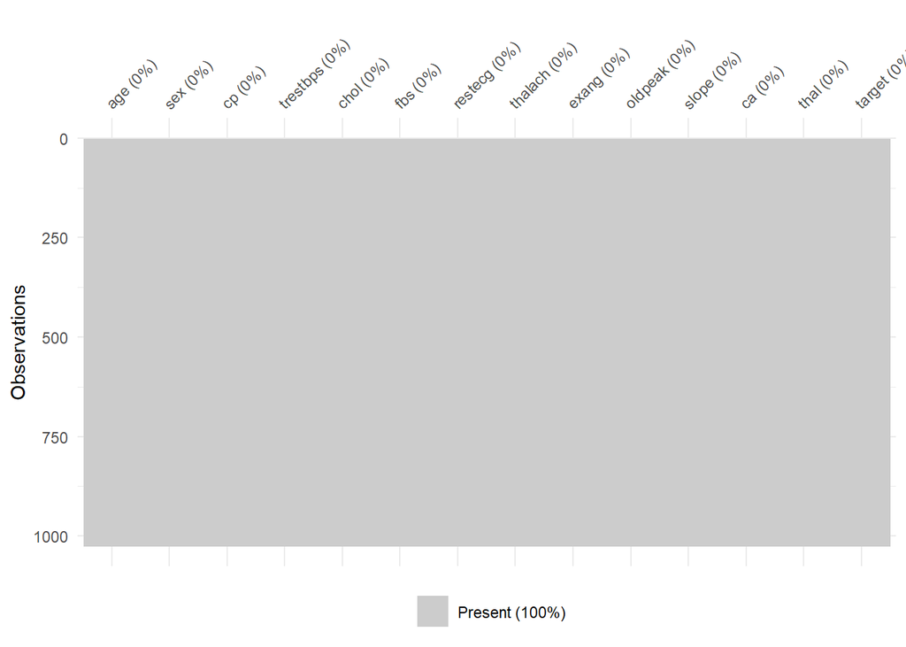

```r
#plot_missing(data)
vis_miss(data)
```

#Transformation

```r
data2 <- data %>%
  mutate(sex = if_else(sex == 1, "MALE", "FEMALE"),
         fbs = if_else(fbs == 1, ">120", "<=120"),
         exang = if_else(exang == 1, "YES" ,"NO"),
         cp = if_else(cp == 1, "ATYPICAL ANGINA",
                      if_else(cp == 2, "NON-ANGINAL PAIN", "ASYMPTOMATIC")),
         restecg = if_else(restecg == 0, "NORMAL",
                           if_else(restecg == 1, "ABNORMALITY", "PROBABLE OR DEFINITE")),
         slope = as.factor(slope),
         ca = as.factor(ca),
         thal = as.factor(thal),
         target = if_else(target == 1, "YES", "NO")
         ) %>%
  mutate_if(is.character, as.factor) %>%
  dplyr::select(target, sex, fbs, exang, cp, restecg, slope, ca, thal, everything())
```

This code modifies the dataset `data` by recoding certain variables and converting them into factors or changing their labels. Here’s what each line does: The changes made are: - Recoding binary variables into descriptive categories (e.g., `sex`, `fbs`, `exang`). - Recoding categorical variables into more readable labels (e.g., `cp`, `restecg`). - Converting certain variables into factors (e.g., `slope`, `ca`, `thal`). - Converting the `target` variable into “YES” or “NO”. - Converting all character variables into factors. - Rearranging columns so that `target`, `sex`, `fbs`, `exang`, `cp`, `restecg`, `slope`, `ca`, `thal`, and other variables are selected in that order.

#Summary Statistics

```r
summary(data2)
```

```
##  target        sex         fbs      exang                    cp
##  NO :499   FEMALE:312   <=120:872   NO :680   ASYMPTOMATIC    :574
##  YES:526   MALE  :713   >120 :153   YES:345   ATYPICAL ANGINA :167
##                                               NON-ANGINAL PAIN:284
##
##
##
##                  restecg    slope   ca      thal         age
##  ABNORMALITY         :513   0: 74   0:578   0:  7   Min.   :29.00
##  NORMAL              :497   1:482   1:226   1: 64   1st Qu.:48.00
##  PROBABLE OR DEFINITE: 15   2:469   2:134   2:544   Median :56.00
##                                     3: 69   3:410   Mean   :54.43
##                                     4: 18           3rd Qu.:61.00
##                                                     Max.   :77.00
##     trestbps          chol        thalach         oldpeak
##  Min.   : 94.0   Min.   :126   Min.   : 71.0   Min.   :0.000
##  1st Qu.:120.0   1st Qu.:211   1st Qu.:132.0   1st Qu.:0.000
##  Median :130.0   Median :240   Median :152.0   Median :0.800
##  Mean   :131.6   Mean   :246   Mean   :149.1   Mean   :1.072
##  3rd Qu.:140.0   3rd Qu.:275   3rd Qu.:166.0   3rd Qu.:1.800
##  Max.   :200.0   Max.   :564   Max.   :202.0   Max.   :6.200
```

#Boxplot

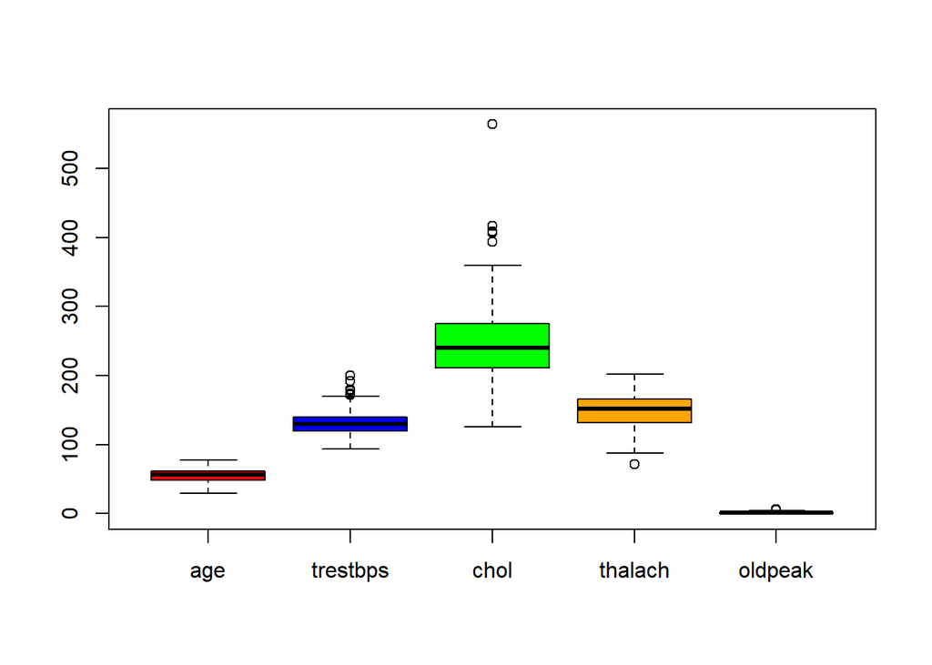

```r
# Define colors for boxplots
colors <- c("red", "blue", "green", "orange", "purple")

# Plot boxplots with different colors
boxplot(data2[, 10:14], col = colors)
```

#Data Visualization

# Bar plot for target (Heart disease)

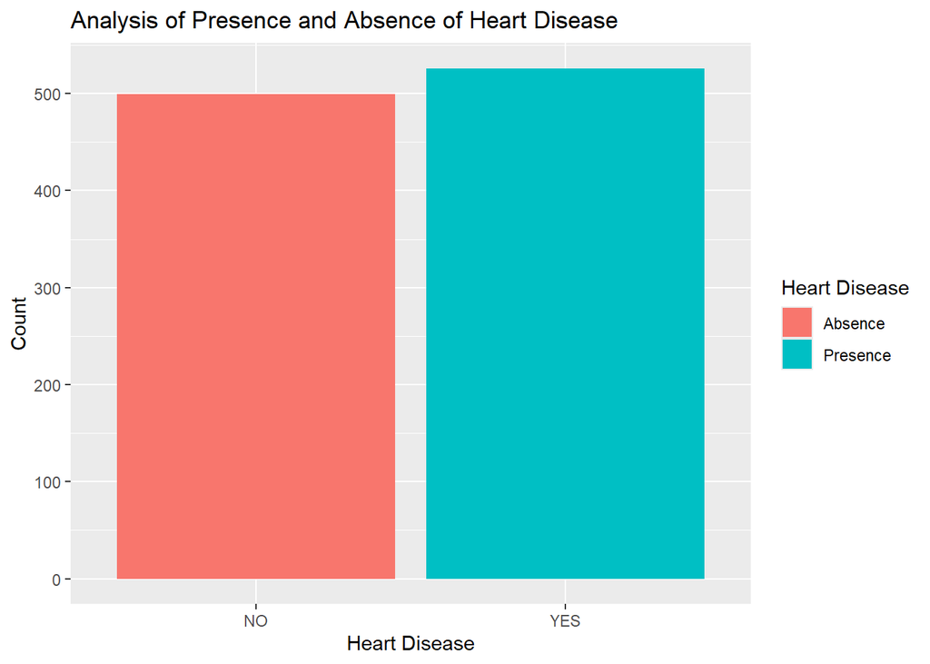

```r
ggplot(data2, aes(x=data2$target, fill=data2$target)) +
  geom_bar() +
  xlab("Heart Disease") +
  ylab("Count") +
  ggtitle("Analysis of Presence and Absence of Heart Disease") +
  scale_fill_discrete(name = "Heart Disease", labels = c("Absence", "Presence"))
```

```r
prop.table(table(data2$target))
```

```
##
##        NO       YES
## 0.4868293 0.5131707
```

# Bar chart of Number of Major Vessels Distribution based on Exercise Induced Angina

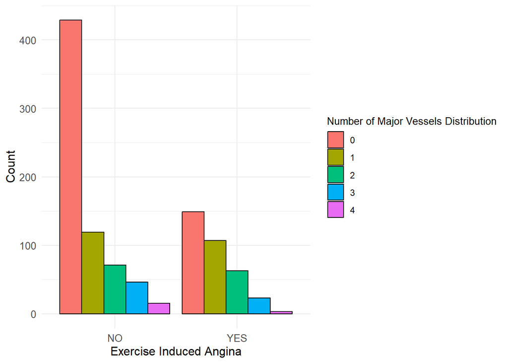

```r
library(ggplot2)
ggplot(data2, aes(x = exang, fill = ca)) +
  geom_bar(position = "dodge", color = "black") +
  labs(x = "Exercise Induced Angina", y = "Count", fill = "Number of Major Vessels Distribution") +
  theme_minimal() +
  theme(legend.position = "right",
        axis.text = element_text(size = 10),
        axis.title = element_text(size = 12),
        legend.title = element_text(size = 10))
```

#Pair Plot of Heart Data with target

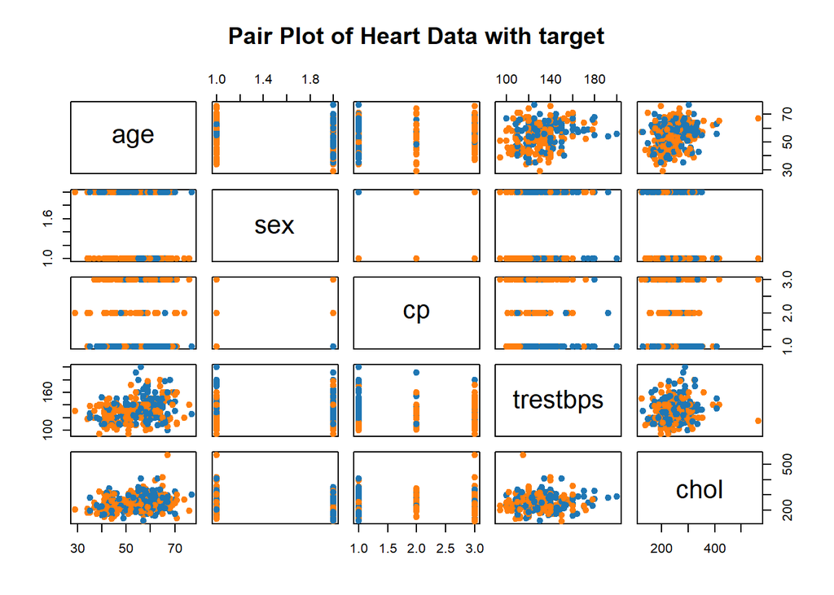

```r
# Subset the data to include only the required variables
heart_subset <- data2[, c('age', 'sex', 'cp', 'trestbps', 'chol', 'target')]

# Define colors for the target variable
colors <- c("HEALTHY" = "#1F77B4", "UNHEALTHY" = "#FF7F0E")

# Convert target variable to factor
heart_subset$target <- factor(heart_subset$target)

# Create pair plot with different color for each target category
pairs(heart_subset[, c('age', 'sex', 'cp', 'trestbps', 'chol')],
      col = colors[as.numeric(heart_subset$target)],
      main = "Pair Plot of Heart Data with target",
      pch = 19)
```

This pair plot visualizes the pairwise relationships between five variables (age, sex, cp, trestbps, and chol) from a heart disease dataset, along with the target variable indicating the presence or absence of heart disease.

Cp (chest pain type): The scatter plots with cp suggest a possible correlation between certain types of chest pain and the target variable, as indicated by the clustering of colors.

# Density plot of resting blood pressure based on slope

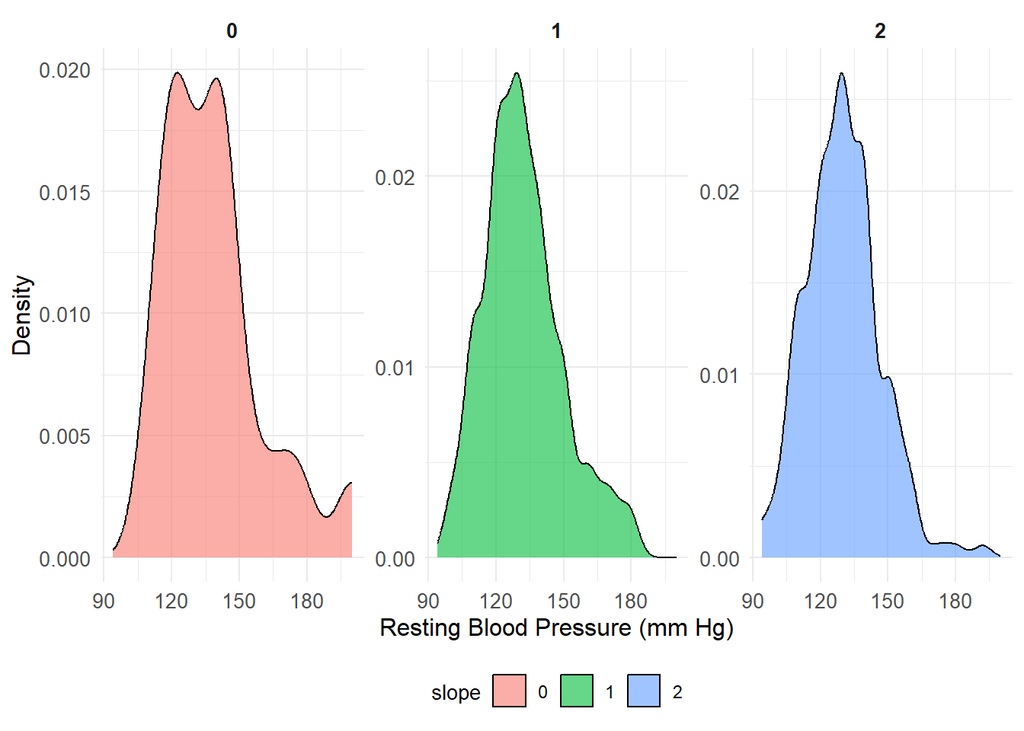

```r
library(ggplot2)
# Density plot of resting blood pressure based on slope
ggplot(data2, aes(x = trestbps, fill = slope)) +
  geom_density(alpha = 0.6, color = "black") +
  labs(x = "Resting Blood Pressure (mm Hg)", y = "Density") +
  facet_wrap(~ slope, scales = "free_y") +
  theme_minimal() +
  theme(legend.position = "bottom",
        axis.text = element_text(size = 10),
        axis.title = element_text(size = 12),
        legend.title = element_text(size = 10),
        strip.text = element_text(size = 10, face = "bold"))
```

Here are some observations about the individual plots: